# Дипломный проект на тему «Автоматизация процесса приема пациентов (на примере ФБГУЗ КБ №85 ФМБА России)»

# Дипломный проект на тему «Автоматизация сбора, обработки и анализа массивов данныхо рекламных активностях на примере компании "МаркетStore"»

### Обучающийся: Николаев Матвей Александрович

### Руководитель: Устинов Евгений Вячеславович

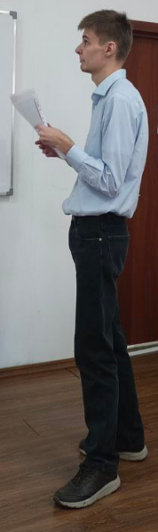

- Какую библиотеку использовали для выгрузки данных в Excel? Она бесплатная?
  - Выяснили, что это Microsoft Office Interop.

# Дипломный проект на тему <<Автоматизация учета компьютерной техники на примере филиала №5 ОСФР по Москве и Московской области >>

### Обучающийся: Сурков Алексей Викторович

### Руководитель: Ребус Наталья Анатольевна

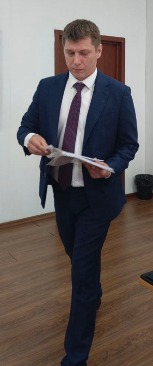

Вопросов нет. Красавец.

# Дипломный проект на тему Автоматизация управления проектамина примереОСФРпо Москвеи Московской области

### Обучающийся: Мартынов Василий Викторович

### Руководитель: Ребус Наталья Анатольевна

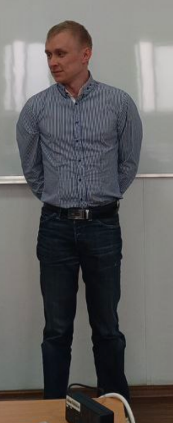

норм

# Выпускная квалификационная работа на тему «Автоматизация взаимоотношений с клиентами на примере копировального центра "Фото Экспресс"»

### Обучающийся: Челюбеев Василий Викторович

### Руководитель: Гринева Елизавета Сергеевна

[figure not shown]

принято

# Дипломный проект на тему «Автоматизация процесса контроля обслуживания техники АО «ТАИФ-НК»

### Обучающийся: Данелов Карлен Арменович

### Руководитеель: Сибирев Иван Валерьевич

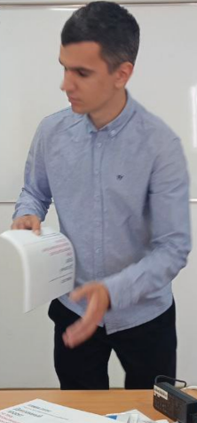

# Дипломный проект на тему «Разработка Информационной системы учета продаж игровых аккаунтов на примере "ООО Фанпей"»

### Обучающийся: Хайдуров Николай Николаевич

### Руководитель: Джебилов Александр Валерьевич

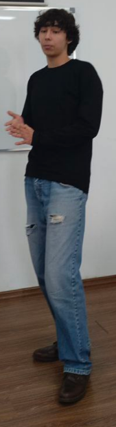

нас учили работать с MySQL